# Lab 4

Ishaan Phadnis

October 4, 2019

# Instructions

**Exercises:** 2,3 (Pg. 151); 2,4 (Pg. 156); 1,2 (Pgs. 160-161); 2 (Pg. 163); 2,3,4 (Pg. 168)

**Submission:** Submit via an electronic document on Sakai. Must be submitted as a HTML file generated in RStudio. All assigned problems are chosen according to the textbook *R for Data Science*. You do not need R code to answer every question. If you answer without using R code, delete the code chunk. If the question requires R code, make sure you display R code. If the question requires a figure, make sure you display a figure. A lot of the questions can be answered in written response, but require R code and/or figures for understanding and explaining.

# Chapter 9 (Pg. 151)

## Exercise 2

```r
#

cases <-
  table2 %>%
  filter(year == 1999,
         type == "cases")
pop <-
  table2 %>%
  filter(year == 1999,
         type == "population")
rate1 <-
  bind_cols(cases, pop) %>%
  mutate(rate = count/count1) %>%
  select(-ends_with("1"), -type)

cases2 <-
  table2 %>%
  filter(year == 2000,
         type == "cases")
pop2 <-
  table2 %>%
  filter(year == 2000,
         type == "population")
rate2 <-
  bind_cols(cases2, pop2) %>%
  mutate(rate = count/count1) %>%
  select(-ends_with("1"), -type)

bind_rows(rate1, rate2)
```

```
## # A tibble: 6 x 4
##   country      year  count      rate
##   <chr>       <int>  <int>     <dbl>
## 1 Afghanistan  1999    745 0.0000373
## 2 Brazil       1999  37737 0.000219
## 3 China        1999 212258 0.000167
## 4 Afghanistan  2000   2666 0.000129
## 5 Brazil       2000  80488 0.000461
## 6 China        2000 213766 0.000167
```

```r
table4a %>% mutate(rate1 = `1999` / table4b$`1999` * 10000, rate2 = `2000` / table4b$`2000` * 10000)
```

```
## # A tibble: 3 x 5
##   country     `1999` `2000` rate1 rate2
##   <chr>        <int>  <int> <dbl> <dbl>
## 1 Afghanistan    745   2666 0.373  1.29
## 2 Brazil       37737  80488 2.19   4.61
## 3 China       212258 213766 1.67   1.67
```

In a way, it’s better to work with ‘’table2’ because we use the filtering techniques to understand the operations. With ‘table4a’ though, this is more condensed. If we wanted to turn the ‘table4a/4b’ result into a more organized version, it would be more complicated.

## Exercise 3

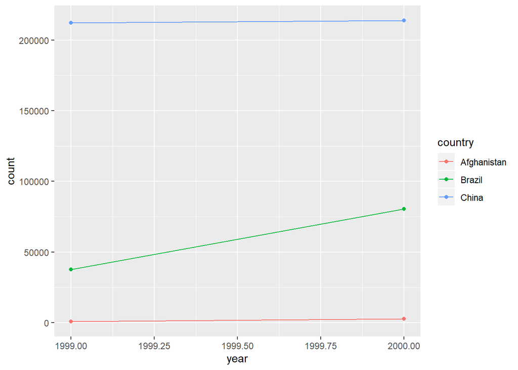

```r
#
table2 %>% filter(type == "cases") %>% ggplot(aes(year, count, group = country, colour = country)) + geom_point() + geom_line()
```

The first thing that needs to be done is to filter for cases.

# Chapter 9 (Pg. 156)

## Exercise 2

```r
#

table4a %>% gather(1999, 2000, key = "year", value = "cases")
```

The reason why this code fails is because ‘gather’ can’t find the names of the columns. The columns can’t be named with numbers in R without quoting them using ’’.

## Exercise 4

```r
#

preg <- tribble(~pregnant, ~male, ~female, "yes", NA, 10, "no", 20, 12)
preg
```

```
## # A tibble: 2 x 3
##   pregnant  male female
##   <chr>    <dbl>  <dbl>
## 1 yes         NA     10
## 2 no          20     12
```

It would make more sense to ‘gather’ the gender column instead of spreading the pregnant column. The variables are pregnancy status and gender.

# Chapter 9 (Pgs. 160-161)

## Exercise 1

```r
#
tibble(x = c("a,b,c", "d,e,f,g", "h,i,j")) %>% separate(x, c("one", "two", "three"))
```

```
## # A tibble: 3 x 3
##   one   two   three
##   <chr> <chr> <chr>
## 1 a     b     c
## 2 d     e     f
## 3 h     i     j
```

```r
tibble(x = c("a,b,c", "d,e", "f,g,i")) %>% separate(x, c("one", "two", "three"))
```

```
## # A tibble: 3 x 3
##   one   two   three
##   <chr> <chr> <chr>
## 1 a     b     c
## 2 d     e     <NA>
## 3 f     g     i
```

Basically, ‘extra’ tells ‘separate()’ what to do if there are too many pieces while ‘fill’ tells ‘separate()’ what to do if there aren’t enough pieces.

## Exercise 2

The ‘remove’ argument basically gets rid of input columns in the result data frame. The reason why it is set to ‘FALSE’ is so that you can create a new variable, but keep the previous one too.

# Chapter 9 (Pg. 163)

## Exercise 2

The ‘direction’ argument (for ‘fill’) determines whether ‘NA’ values should be replaced by the previous non-empty value (“down”) or the next non-empty value (“up”).

# Chapter 9 (Pg. 168)

## Exercise 2

```r
#
mutate(key = stringr::str_replace(key, "newrel", "new_rel"))
```

## Exercise 3

```r
#
who %>% count(country, iso2, iso3) %>% count(country) %>% filter(n > 1)
```

```
## # A tibble: 0 x 2
## # ... with 2 variables: country <chr>, n <int>
```

If there were repetitions of country, then this value would be equal to greater than 1, which is not in this case. Therefore, ‘iso2’ and ‘iso3’ are redundant.

## Exercise 4

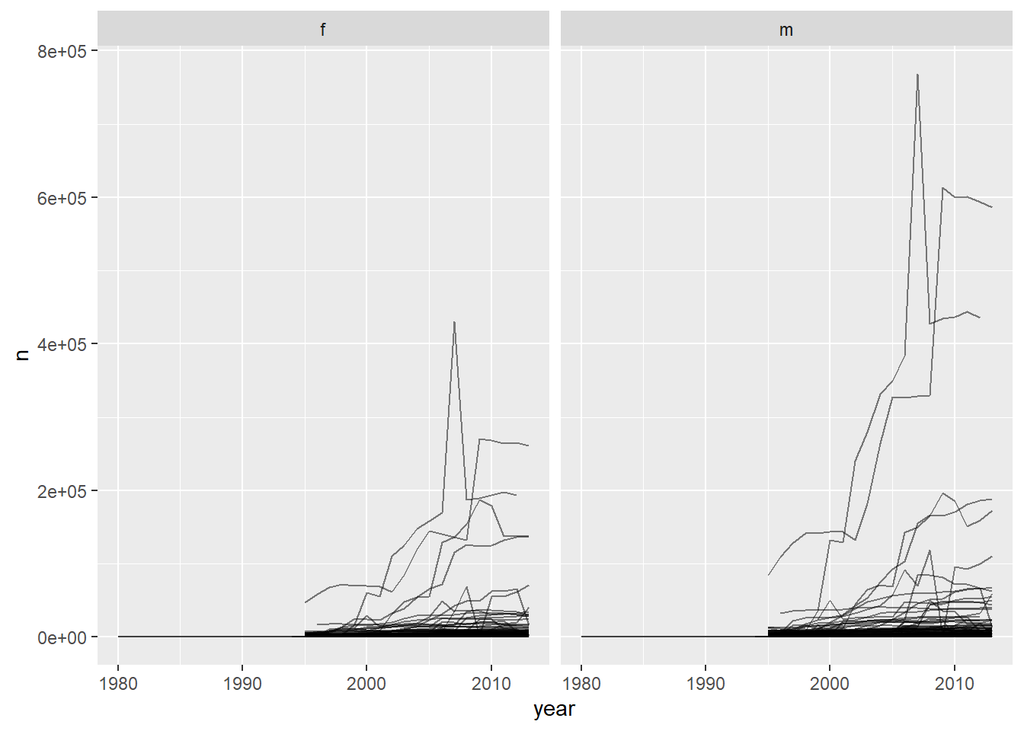

```r
#
visual <- who %>% gather(new_sp_m014:newrel_f65, key = "key", value = "cases", na.rm = TRUE) %>% mutate(key = stringr::str_replace(key, "newrel", "new_rel")) %>% separate(key, c("new", "type", "sexage"), sep = "_") %>% select(-new, -iso2, -iso3) %>% separate(sexage, c("sex", "age"), sep = 1)

visual %>% group_by(country, year, sex) %>% summarize(n = sum(cases)) %>% ggplot(aes(year, n, group = country)) + geom_line(alpha = 2/4) + facet_wrap(~ sex)
```